# Homework 2 Solution

Aleksandr Shemendyuk

2023-10-30

# 1 Inventory Management Simulation

Let’s simulate the apple inventory management over a span of 52 weeks for FreshMart.

We will start by initializing our variables:

```r
# Initial values
inventory <- 500
weeks <- 52
total_sales <- 0
total_orders <- 0
order_status <- FALSE
weeks_until_delivery <- 0

# Vectors to store weekly data
weekly_sales_vector <- numeric(weeks)
deliveries_received_vector <- numeric(weeks)
remaining_inventory_vector <- numeric(weeks)
```

Now, let’s run our simulation:

```r
# Fix the seed
set.seed(123)

# Run the simulation
for (week in 1:weeks) {
  # Generate non-negative sales following a normal distribution
  weekly_sales <- max(0, round(rnorm(1, mean=100, sd=15)))

  # Check if demand exceeds available inventory
  weekly_sales <- min(weekly_sales, inventory)

  # Reduce inventory by weekly sales
  inventory <- inventory - weekly_sales
  total_sales <- total_sales + weekly_sales

  # Store weekly sales data
  weekly_sales_vector[week] <- weekly_sales

  # Check if order arrives
  if (order_status && weeks_until_delivery == 0) {
    inventory <- inventory + 300
    order_status <- FALSE
    deliveries_received_vector[week] <- 300
  } else if (order_status) {
    weeks_until_delivery <- weeks_until_delivery - 1
    deliveries_received_vector[week] <- 0
  } else {
    deliveries_received_vector[week] <- 0
  }

  # Check if new order should be placed
  if (inventory < 400 && !order_status) {
    order_status <- TRUE
    weeks_until_delivery <- 2
    total_orders <- total_orders + 1
  }

  # Store remaining inventory data
  remaining_inventory_vector[week] <- inventory
}
```

Finally, let’s present our annual report using the `kable` package:

```r
annual_report <- tibble(
  Week = 1:weeks,
  `Apples Sold` = weekly_sales_vector,
  `Deliveries Received` = deliveries_received_vector,
  `Remaining Inventory` = remaining_inventory_vector
)

kable(annual_report, caption = "Annual Report for FreshMart's Apple Inventory", align = 'c')
```

Annual Report for FreshMart’s Apple Inventory

| Week | Apples Sold | Deliveries Received | Remaining Inventory |
| --- | --- | --- | --- |
| 1 | 92 | 0 | 408 |
| 2 | 97 | 0 | 311 |
| 3 | 123 | 0 | 188 |
| 4 | 101 | 0 | 87 |
| 5 | 87 | 300 | 300 |
| 6 | 126 | 0 | 174 |
| 7 | 107 | 0 | 67 |
| 8 | 67 | 300 | 300 |
| 9 | 90 | 0 | 210 |
| 10 | 93 | 0 | 117 |
| 11 | 117 | 300 | 300 |
| 12 | 105 | 0 | 195 |
| 13 | 106 | 0 | 89 |
| 14 | 89 | 300 | 300 |
| 15 | 92 | 0 | 208 |
| 16 | 127 | 0 | 81 |
| 17 | 81 | 300 | 300 |
| 18 | 71 | 0 | 229 |
| 19 | 111 | 0 | 118 |
| 20 | 93 | 300 | 325 |
| 21 | 84 | 0 | 241 |
| 22 | 97 | 0 | 144 |
| 23 | 85 | 300 | 359 |
| 24 | 89 | 0 | 270 |
| 25 | 91 | 0 | 179 |
| 26 | 75 | 300 | 404 |
| 27 | 113 | 0 | 291 |
| 28 | 102 | 0 | 189 |
| 29 | 83 | 0 | 106 |
| 30 | 106 | 300 | 300 |
| 31 | 106 | 0 | 194 |
| 32 | 96 | 0 | 98 |
| 33 | 98 | 300 | 300 |
| 34 | 113 | 0 | 187 |
| 35 | 112 | 0 | 75 |
| 36 | 75 | 300 | 300 |
| 37 | 108 | 0 | 192 |
| 38 | 99 | 0 | 93 |
| 39 | 93 | 300 | 300 |
| 40 | 94 | 0 | 206 |
| 41 | 90 | 0 | 116 |
| 42 | 97 | 300 | 319 |
| 43 | 81 | 0 | 238 |
| 44 | 133 | 0 | 105 |
| 45 | 105 | 300 | 300 |
| 46 | 83 | 0 | 217 |
| 47 | 94 | 0 | 123 |
| 48 | 93 | 300 | 330 |
| 49 | 112 | 0 | 218 |
| 50 | 99 | 0 | 119 |
| 51 | 104 | 300 | 315 |
| 52 | 100 | 0 | 215 |

# 2 Bees

## 2.1 Load the libraries

```r
library(dplyr)
library(ggplot2)
library(tidyr)
```

## 2.2 Load the data

📊 Load the three data sets `dat_bee_max`, `dat_bee_varroa`, and `dat_bee_loss` into your `R` environment using `load("dataset.rda")`.

```r
load(here::here("dat_bee_loss.rda"))
load(here::here("dat_bee_max.rda"))
load(here::here("dat_bee_varroa.rda"))
```

## 2.3 Merge the data

⚙️ Preprocess the datasets before merging. This may include resolving duplicates, pivoting data, transforming variables, renaming variables etc.

```r
# Remove duplicated
dat_bee_varroa <- dat_bee_varroa[!duplicated(dat_bee_varroa), ]
dat_bee_max <- dat_bee_max[!duplicated(dat_bee_max), ]

# Transform varroa from percentage to proportion
dat_bee_varroa$varroa <- dat_bee_varroa$varroa / 100

# Restore to long format
dat_bee_loss <- dat_bee_loss %>%
  pivot_longer(
    cols = names(dat_bee_loss)[-(1:3)],
    names_to = "state",
    values_to = "num_lost_colonies"
  )

# Merge
dat_comb <- dat_bee_varroa %>%
  left_join(dat_bee_loss, by = c("state", "region", "year", "period"))
dat_comb <- dat_comb %>%
  left_join(dat_bee_max, by = c("state", "region", "year", "period"))

datdes <- dat_comb
```

## 2.4 Remove missing data and Inf

🧹 Eliminate missing data and non-finite values from the datasets post-merging.

👆 Conduct the necessary data wrangling steps to end up with a dataset that resembles the provided example. It should have dimensions $1186 \times 7$.

```r
indnum <- sapply(datdes, is.numeric)
datdes <- datdes[is.finite(rowSums(datdes[, indnum])), ]
datdes$period <- as.factor(datdes$period)
head(datdes)
```

|  | state | year | region | period | varroa | num_lost_colonies | num_max_colonies |
| --- | --- | --- | --- | --- | --- | --- | --- |
| 1 | Idaho | 2016 | Northwest | 3 | 0.253 | 13000 | 131000 |
| 2 | Washington | 2018 | Northwest | 4 | 0.345 | 11000 | 81000 |
| 3 | Vermont | 2015 | Northeast | 2 | 0.037 | 100 | 6000 |
| 4 | Virginia | 2018 | Southeast | 2 | 0.227 | 500 | 6000 |
| 5 | Arizona | 2021 | Southwest | 2 | 0.074 | 4300 | 26000 |
| 6 | Arizona | 2017 | Southwest | 4 | 0.616 | 6500 | 30000 |

## 2.5 Empirical distribution of the proportion of honey bee colony loss

🖼️ Craft a graph representing the empirical distribution of the proportion of honey bee colony loss with respect to the quarters and climatic regions

📈 Incorporate a red dashed line in your graph to represent the median of the honey bee colony loss proportion.

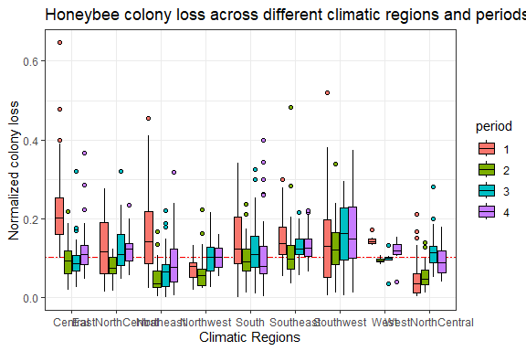

```r
cutoff <- median(datdes$num_lost_colonies / datdes$num_max_colonies)

p1 <- ggplot(datdes, aes(
  x = region, y = num_lost_colonies / num_max_colonies,
  color = period, fill = period
)) +
  geom_hline(yintercept = cutoff, color = "red", linetype = "twodash") +
  geom_boxplot(
    lwd = 0.1, width = 0.75, alpha = 1,
    outlier.size = 1.5, outlier.alpha = 1, outlier.shape = 21,
    color = "black"
  ) +
  ylab("Normalized colony loss") +
  xlab("Climatic Regions") +
  ggtitle("Honeybee colony loss across different climatic regions and periods") +
  theme_bw()
p1
```

# 3 Hilbert matrix

- 📝 Write a function named `hilbert_matrix` which computes a Hilbert matrix of `dim_mat` rows and `dim_mat` columns. Take `dim_mat` as a single positive integer argument using `for` loops. Run `hilbert_matrix(10)`.
- 🛠 Modify the function to print a console message before beginning the computation, issue a warning if a positive double is input, or raise an error if input is neither a positive double nor a positive integer. Test `hilbert_matrix(10L)`, `hilbert_matrix(10)`, `hilbert_matrix("10")`.
- 🧮 Based on an observation regarding the denominator trends in Hilbert matrix elements, propose a new implementation without `for` loops using `rep` and `seq`.
- 🚀 Compare the execution performance of your solutions in the above steps.
- Use `profvis::profvis({...})` to profile each function, replacing `...` with your code. Comment on the aspects of memory usage and computation time.
- Use `microbenchmark::microbenchmark({...}, {...})` for benchmarking, replacing `...` with your implementations. Discuss the resulting outputs.

## 3.1 Solution with a loop

```r
hilbert_matrix_loop <- function(dim_mat) {
    # Input validation
    if (!is.numeric(dim_mat) || dim_mat <= 0) {
        stop("Input must be a positive integer or double.")
    }

    # Computation
    mat <- matrix(NA_real_, nrow = dim_mat, ncol = dim_mat)

    for (i in 1:dim_mat) {
        for (j in 1:dim_mat) {
            mat[i, j] <- 1 / (i + j - 1)
        }
    }

    return(mat)
}
```

## 3.2 Solution without a slightly improved loop

```r
hilbert_matrix_loop_faster <- function(dim_mat) {
    # Input validation
    if (!is.numeric(dim_mat) || dim_mat <= 0) {
        stop("Input must be a positive integer or double.")
    }

    # Computation
    mat <- matrix(NA_real_, nrow = dim_mat, ncol = dim_mat)

    for (i in 1:dim_mat) {
        mat[i, ] <- 1 / (i + 1:dim_mat - 1)
    }

    return(mat)
}
```

## 3.3 Solution using `rep` and `seq`

```r
hilbert_matrix_seq <- function(dim_mat) {
    # Input validation
    if (!is.numeric(dim_mat) || dim_mat <= 0) {
        stop("Input must be a positive integer or double.")
    }

    # Computation
    x <- rep(seq_len(dim_mat), dim_mat) + rep(seq_len(dim_mat), each = dim_mat) - 1
    mat <- matrix(1 / x, nrow = dim_mat, ncol = dim_mat)

    return(mat)
}
```

## 3.4 Profile and benchmark

Use `profvis::profvis({...})` to profile each function, replacing `...` with your code. Comment on the aspects of memory usage and computation time.

```r
dim_mat <- 10e3
profvis::profvis({
    hilbert_matrix_loop(dim_mat)
    hilbert_matrix_loop_faster(dim_mat)
    hilbert_matrix_seq(dim_mat)
})
```

[interactive chart not shown]

Use `microbenchmark::microbenchmark({...}, {...})` for benchmarking, replacing `...` with your implementations. Discuss the resulting outputs.

```r
dim_mat <- 10e2
benchmark_resulst <-  microbenchmark::microbenchmark(
    hilbert_matrix_loop(dim_mat),
    hilbert_matrix_loop_faster(dim_mat),
    hilbert_matrix_seq(dim_mat),
    times = 100
)
```

Display the benchmark results.

```r
benchmark_resulst %>%
    summary() %>%
    kable() %>%
    kable_styling()
```

| expr | min | lq | mean | median | uq | max | neval |
| --- | --- | --- | --- | --- | --- | --- | --- |
| hilbert_matrix_loop(dim_mat) | 49.429501 | 50.71035 | 57.28927 | 51.6962 | 57.02520 | 175.6640 | 100 |
| hilbert_matrix_loop_faster(dim_mat) | 8.725002 | 10.35445 | 13.01838 | 11.6158 | 13.85805 | 43.4673 | 100 |
| hilbert_matrix_seq(dim_mat) | 14.516501 | 14.83560 | 24.20828 | 16.5293 | 20.15245 | 316.8191 | 100 |